# **By Zijia Chen (zc2521) & Qingyuan Dong (qd2145)**

## This project is prompted to test kernelization on k-means

k-means with Euclidean distance metric assumes that each pair of clusters is linearly separable. This may not be the case. A classic example is where we have two clusters corresponding to data points on two concentric circles in the R2.

### Prompt(i). Implement Lloyd’s method for k-means algorithm and show the resulting cluster assignment for the dataset depicted above. Give two more examples of datasets in R2, for which optimal k-means setting results in an undesirable clustering. Show the resulting cluster assignment for the two additional example datasets.

#### Reference used:

- k-mean cluster visualization https://jakevdp.github.io/PythonDataScienceHandbook/05.11-k-means.html
- sklearn.dataset.make_classification https://scikit-learn.org/stable/modules/generated/sklearn.datasets.make_classification.html#sklearn.datasets.make_classification

```python
import numpy as np
%matplotlib inline
import matplotlib.pyplot as plt
import seaborn as sns; sns.set()  # for plot styling
```

## Example 1: concentric circles in the R2

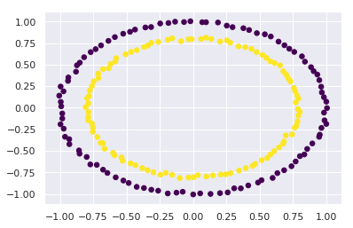

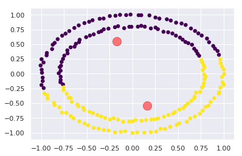

```python
# generate sample data
from sklearn.datasets import make_circles

X1, y1 = make_circles(n_samples=200, noise=0.01, random_state=0)
plt.scatter(X1[:, 0], X1[:, 1], c=y1,
            s=30, cmap='viridis')
plt.show()

# fit kmeans clustering model
from sklearn.cluster import KMeans
kmeans = KMeans(2, random_state=0)
labels = kmeans.fit_predict(X1)

# plot kmeans result
plt.scatter(X1[:, 0], X1[:, 1], c=labels,
            s=30, cmap='viridis')
centers = kmeans.cluster_centers_
plt.scatter(centers[:, 0], centers[:, 1], c='red', s=200, alpha=0.5)
```

## Example 2：interleaving half circles in R2

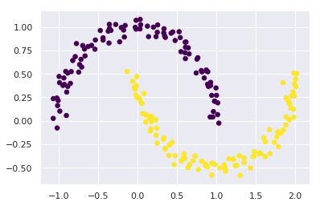

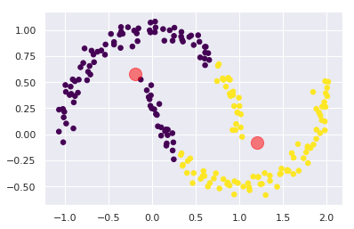

```python
# generate sample data
from sklearn.datasets import make_moons
X2, y2 = make_moons(200, noise=.05, random_state=0)
plt.scatter(X2[:, 0], X2[:, 1], c=y2,
            s=30, cmap='viridis')
plt.show()

# fit kmeans clustering model
kmeans = KMeans(2, random_state=0)
labels = kmeans.fit_predict(X2)

# plot kmeans result
plt.scatter(X2[:, 0], X2[:, 1], c=labels,
            s=30, cmap='viridis')
centers = kmeans.cluster_centers_
plt.scatter(centers[:, 0], centers[:, 1], c='red', s=200, alpha=0.5)
```

## Example 3: informative lines in R2

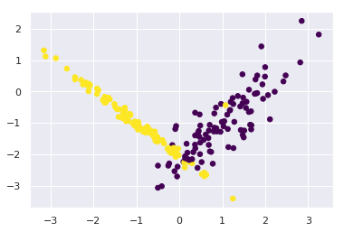

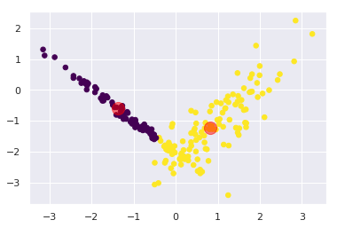

```python
# generate sample data
from sklearn.datasets import make_classification
X3, y3 = make_classification(200, n_features=2, n_redundant=0, n_informative=2,
                             n_clusters_per_class=1, random_state=478)
plt.scatter(X3[:, 0], X3[:, 1], c=y3,
            s=30, cmap='viridis')
plt.show()

# fit kmeans clustering model
kmeans = KMeans(2, random_state=0)
labels = kmeans.fit_predict(X3)

# plot kmeans result
plt.scatter(X3[:, 0], X3[:, 1], c=labels,
            s=30, cmap='viridis')
centers = kmeans.cluster_centers_
plt.scatter(centers[:, 0], centers[:, 1], c='red', s=200, alpha=0.5)
```

### (vi). Implement your proposed kernelized k-means method and run it on the three example datasets of part (i). Compare the resulting cluster for various choices of kernels (e.g. linear kernel, quadratic kernel, rbf kernel).

#### Reference:

- kernel k-mean from scratch https://github.com/ardianumam/Machine-Learning-From-The-Scratch/blob/master/kernel_kMeansClustering.py
- sklearn.cluster.SpectralClustering https://scikit-learn.org/stable/modules/generated/sklearn.cluster.SpectralClustering.html

```python
# define functions for kernelizing k-mean
from matplotlib import pyplot as plt
from matplotlib.pyplot import cm
import time

#params
var=5
k = 2 #number of cluster
initMethod = "byOriginDistance" #options = random, byCenterDistance, byOriginDistance

def initCluster(dataInput, nCluster, method):
    listClusterMember = [[] for i in range(nCluster)]
    if (method == "random"):
        shuffledDataIn = dataInput
        np.random.shuffle(shuffledDataIn)
        for i in range(0, dataInput.shape[0]):
            listClusterMember[i%nCluster].append(dataInput[i,:])
    if (method == "byCenterDistance"):
        center = np.matrix(np.mean(dataInput, axis=0))
        repeatedCent = np.repeat(center, dataInput.shape[0], axis=0)
        deltaMatrix = abs(np.subtract(dataInput, repeatedCent))
        euclideanMatrix = np.sqrt(np.square(deltaMatrix).sum(axis=1))
        dataNew = np.array(np.concatenate((euclideanMatrix, dataInput), axis=1))
        dataNew = dataNew[np.argsort(dataNew[:, 0])]
        dataNew = np.delete(dataNew, 0, 1)
        divider = dataInput.shape[0]/nCluster
        for i in range(0, dataInput.shape[0]):
            listClusterMember[np.int(np.floor(i/divider))].append(dataNew[i,:])
    if (method == "byOriginDistance"):
        origin = np.matrix([[0,0]])
        repeatedCent = np.repeat(origin, dataInput.shape[0], axis=0)
        deltaMatrix = abs(np.subtract(dataInput, repeatedCent))
        euclideanMatrix = np.sqrt(np.square(deltaMatrix).sum(axis=1))
        dataNew = np.array(np.concatenate((euclideanMatrix, dataInput), axis=1))
        dataNew = dataNew[np.argsort(dataNew[:, 0])]
        dataNew = np.delete(dataNew, 0, 1)
        divider = dataInput.shape[0]/nCluster
        for i in range(0, dataInput.shape[0]):
            listClusterMember[np.int(np.floor(i/divider))].append(dataNew[i,:])

    return listClusterMember

def RbfKernel(data1, data2, sigma):
    delta =abs(np.subtract(data1, data2))
    squaredEuclidean = (np.square(delta).sum(axis=1))
    result = np.exp(-(squaredEuclidean)/(2*sigma**2))
    return result

def LinearKernel(data1, data2, constant):
    d1 = np.array(data1).reshape(2,)
    d2 = np.array(data2).reshape(2,)
    result = np.asmatrix(np.dot(d1,d2)+constant)
    return result

def QuadraticKernel(data1, data2, constant):
    d1 = np.array(data1).reshape(2,)
    d2 = np.array(data2).reshape(2,)
    result = np.asmatrix((np.dot(d1, d2)+constant)**2)
    return result

def thirdTerm(memberCluster, kernel):
    result = 0
    for i in range(0, memberCluster.shape[0]):
        for j in range(0, memberCluster.shape[0]):
            result = result + kernel(memberCluster[i, :], memberCluster[j, :], var)
    result = result / (memberCluster.shape[0] ** 2)
    return result

def secondTerm(dataI, memberCluster, kernel):
    result = 0
    for i in range(0, memberCluster.shape[0]):
        result = result + kernel(dataI, memberCluster[i,:], var)
    result = 2 * result / memberCluster.shape[0]
    return result

def plotResult(listClusterMembers, centroid, iteration, converged, title):
    n = listClusterMembers.__len__()
    color = iter(cm.rainbow(np.linspace(0, 1, n)))
    plt.figure("result")
    plt.clf()
    plt.title(title)
    for i in range(n):
        col = next(color)
        memberCluster = np.asmatrix(listClusterMembers[i])
        plt.scatter(np.ravel(memberCluster[:, 0]), np.ravel(memberCluster[:, 1]), marker=".", s=100, c=col)
    color = iter(cm.rainbow(np.linspace(0, 1, n)))
    for i in range(n):
        col = next(color)
        plt.scatter(np.ravel(centroid[i, 0]), np.ravel(centroid[i, 1]), marker="*", s=400, c=col, edgecolors="black")
    if (converged == 0):
        plt.ion()
        plt.show()
        plt.pause(0.1)
    if (converged == 1):
        plt.show(block=True)

def kMeansKernel(data, initMethod, kernel):
    global iterationCounter
    memberInit = initCluster(data, k, initMethod)
    nCluster = memberInit.__len__()
    iterationCounter = 0
    #looping until converged
    while(True):
        # calculate centroid, only for visualization purpose
        centroid = np.ndarray(shape=(0, data.shape[1]))
        for i in range(0, nCluster):
            memberCluster = np.asmatrix(memberInit[i])
            centroidCluster = memberCluster.mean(axis=0)
            centroid = np.concatenate((centroid, centroidCluster), axis=0)
        #plot result in every iteration
        #plotResult(memberInit, centroid, str(iterationCounter), 0)
        oldTime = np.around(time.time(), decimals=0)
        kernelResultClusterAllCluster = np.ndarray(shape=(data.shape[0], 0))
        #assign data to cluster whose centroid is the closest one
        for i in range(0, nCluster):#repeat for all cluster
            term3 = thirdTerm(np.asmatrix(memberInit[i]), kernel)
            matrixTerm3 = np.repeat(term3, data.shape[0], axis=0); matrixTerm3 = np.asmatrix(matrixTerm3)
            matrixTerm2 = np.ndarray(shape=(0,1))
            for j in range(0, data.shape[0]): #repeat for all data
                term2 = secondTerm(data[j,:], np.asmatrix(memberInit[i]), kernel)
                matrixTerm2 = np.concatenate((matrixTerm2, term2), axis=0)
            matrixTerm2 = np.asmatrix(matrixTerm2)
            kernelResultClusterI = np.add(-1*matrixTerm2, matrixTerm3)
            kernelResultClusterAllCluster =\
                np.concatenate((kernelResultClusterAllCluster, kernelResultClusterI), axis=1)
        clusterMatrix = np.ravel(np.argmin(np.matrix(kernelResultClusterAllCluster), axis=1))
        listClusterMember = [[] for l in range(k)]
        for i in range(0, data.shape[0]):#assign data to cluster regarding cluster matrix
            listClusterMember[np.asscalar(clusterMatrix[i])].append(data[i,:])
#         for i in range(0, nCluster):
#             print("Cluster member numbers-", i, ": ", listClusterMember[0].__len__())
        #break when converged
        boolAcc = True
        for m in range(0, nCluster):
            prev = np.asmatrix(memberInit[m])
            current = np.asmatrix(listClusterMember[m])
            if (prev.shape[0] != current.shape[0]):
                boolAcc = False
                break
            if (prev.shape[0] == current.shape[0]):
                boolPerCluster = (prev == current).all()
            boolAcc = boolAcc and boolPerCluster
            if(boolAcc==False):
                break
        if(boolAcc==True):
            break
        iterationCounter += 1
        #update new cluster member
        memberInit = listClusterMember
        newTime = np.around(time.time(), decimals=0)
#         print("iteration-", iterationCounter, ": ", newTime - oldTime, " seconds")
    return listClusterMember, centroid
```

### Linear kernel for 3 examples

```
Linear kernel kmeans:
```

[output not shown]

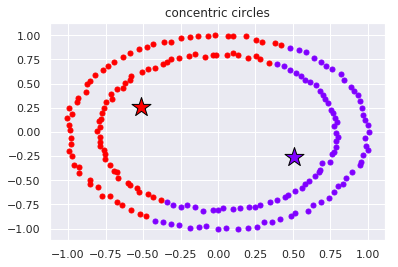

[output not shown]

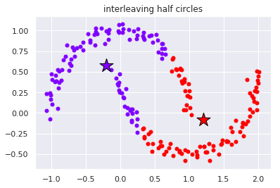

[output not shown]

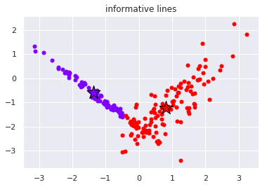

```python
print('Linear kernel kmeans:')
# Example 1
clusterResult, centroid = kMeansKernel(X1, initMethod, LinearKernel)
plotResult(clusterResult, centroid, str(iterationCounter) + ' (converged)', 1, 'concentric circles')

# Example 2
clusterResult, centroid = kMeansKernel(X2, initMethod, LinearKernel)
plotResult(clusterResult, centroid, str(iterationCounter) + ' (converged)', 1, 'interleaving half circles')

# Example 3
clusterResult, centroid = kMeansKernel(X3, initMethod, LinearKernel)
plotResult(clusterResult, centroid, str(iterationCounter) + ' (converged)', 1, 'informative lines')
```

### Quadratic kernel for 3 examples

```
Quadratic kernel kmeans:
```

[output not shown]

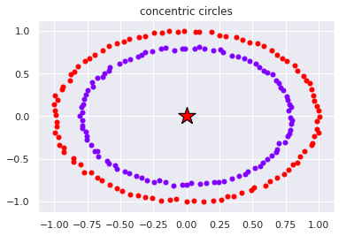

[output not shown]

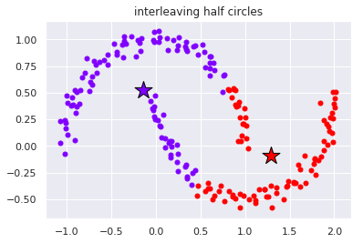

[output not shown]

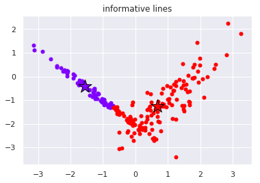

```python
print('Quadratic kernel kmeans:')
# Example 1
clusterResult, centroid = kMeansKernel(X1, initMethod, QuadraticKernel)
plotResult(clusterResult, centroid, str(iterationCounter) + ' (converged)', 1, 'concentric circles')

# Example 2
clusterResult, centroid = kMeansKernel(X2, initMethod, QuadraticKernel)
plotResult(clusterResult, centroid, str(iterationCounter) + ' (converged)', 1, 'interleaving half circles')

# Example 3
clusterResult, centroid = kMeansKernel(X3, initMethod, QuadraticKernel)
plotResult(clusterResult, centroid, str(iterationCounter) + ' (converged)', 1, 'informative lines')
```

### RBF kernel for 3 examples

```
RBF kernel kmeans:
```

[output not shown]

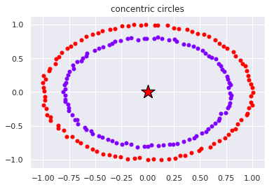

[output not shown]

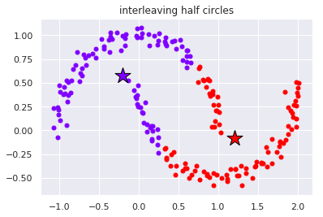

[output not shown]

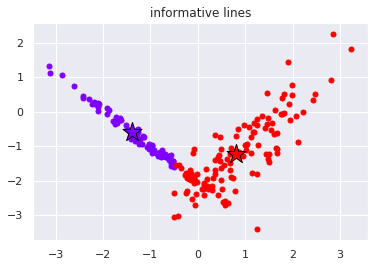

```python
print('RBF kernel kmeans:')
# Example 1
clusterResult, centroid = kMeansKernel(X1, initMethod, RbfKernel)
plotResult(clusterResult, centroid, str(iterationCounter) + ' (converged)', 1, 'concentric circles')

# Example 2
clusterResult, centroid = kMeansKernel(X2, initMethod, RbfKernel)
plotResult(clusterResult, centroid, str(iterationCounter) + ' (converged)', 1, 'interleaving half circles')

# Example 3
clusterResult, centroid = kMeansKernel(X3, initMethod, RbfKernel)
plotResult(clusterResult, centroid, str(iterationCounter) + ' (converged)', 1, 'informative lines')
```

[output not shown]

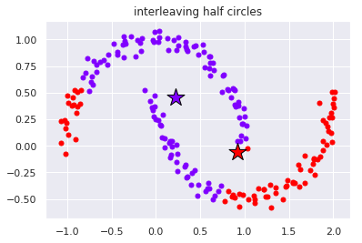

```python
var = 0.5
clusterResult, centroid = kMeansKernel(X2, initMethod, RbfKernel)
plotResult(clusterResult, centroid, str(iterationCounter) + ' (converged)', 1, 'interleaving half circles')
```

### Prompt(ii). Utilize the concept of Gradient Descent to predict the location of the city using distance between cities

Reference:

- Gredient descent https://towardsdatascience.com/gradient-descent-in-python-a0d07285742f

```python
   D = [[0,206,429,1504,963,2976,3095,2979,1949],

              [206,0,233,1308,802,2815,2934,2786,1771],

              [429,233,0,1075,671,2684,2799,2631,1616],

              [1504,1308,1075,0,1329,3273,3053,2687,2037],

              [963,802,671,1329,0,2013,2142,2054,996],

              [2976,2815,2684,3273,2013,0,808,1131,1307],

              [3095,2934,2799,3053,2142,808,0,379,1235],

              [2979,2786,2631,2687,2054,1131,379,0,1059],

              [1949,1771,1616,2037,996,1307,1235,1059,0]]
```

```python
def gradient_descent(X, Distance, learning_rate, iteration):
    for it in range(iteration):
        for i in range(len(X)):
            derivative = np.array([0,0])
            for j in range(len(X)):
                if j != i:
                    derivative = derivative + (1-Distance[i][j]/np.linalg.norm(X[i]-X[j]))*(X[i]-X[j])
            X[i] = X[i] - learning_rate * derivative

    return X

def call_cost(X, Distance):
  cost = 0
  for i in range(len(X)):
    for j in range(len(X)):
      cost = cost + (np.linalg.norm(X[i]-X[j])-Distance[i][j])**2
  return cost
```

```python
lr = 0.01
n_iter = 10000
X = np.random.randn(9,2)

loc = gradient_descent(X, D, lr, n_iter)
loc
```

```
array([[-1366.2435843 ,  -505.66183428],
       [-1226.76785363,  -343.57907174],
       [-1110.15268223,  -134.4068257 ],
       [-1259.8722253 ,   961.8157067 ],
       [ -457.09214397,  -153.06629181],
       [ 1567.83502539,  -632.4040741 ],
       [ 1674.10769845,   176.57187387],
       [ 1440.58040261,   499.26290951],
       [  495.34789247,    35.19373346]])
```

```python
call_cost(loc, D)
```

```
56374.08800260328
```

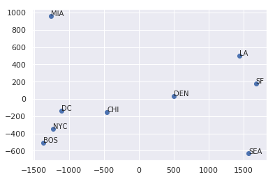

```python
cities=['BOS','NYC','DC','MIA','CHI','SEA','SF','LA','DEN']

for c,type in enumerate(cities):
    x = loc[:,0][c]
    y = loc[:,1][c]
    plt.plot(x, y, 'bo')
    plt.text(x, y, type, fontsize=10)
plt.show()
```